# h3

**Put any package imports you need in the below space**

```python
#!pip install python-igraph
from igraph import *
import matplotlib.pyplot as plt
%matplotlib inline
import numpy as np
```

**Exercise 1**: Generating the adjacency matrix A for graphs of particular type. Write a script that generates the adjacency matrix A for each of the following graphs and prints this matrix onto the screen:

1. K5: 5-clique, or a fully connected simple, undirected graph of 5 nodes
2. K5.3: two disconnected components, C1 and C2, where C1 is a 5-clique K5 and C2 is a 3-clique K3
3. K5.3e: Almost the same as K53 but there is a single edge connecting the two components
4. B2.3: Complete bi-partite graph with n1=2 nodes in the first part and n2=3 nodes in the second part
5. S5: A 5-vertex star (one central "hub" node that connects to all the other "spoke" nodes)
6. P5: A simple path of 5 vertices

```python
## 1.creating adjacency matrix for a 5-clique fully connected simple graph
C1 = Graph.Full(5)
Graph_k5=C1.get_adjacency()
print("Adjacency matrix for 5- clique fully connected simple graph with undirected edges Graph_k5,",Graph_k5)

## 2.creating adjacency matrix for  two disconnected components, C1 and C2, where C1 is a 5-clique K5 and C2 is a 3-clique K3
C2 = Graph.Full(3)
K5_3 = C1+C2
Graph_K5_3=K5_3.get_adjacency()
print("Adjacency matrix for two disconnected components, C1 and C2",Graph_K5_3)


## 3.creating adjacency matrix for a K5.3e, adding the edge (4,5) connecting the two  connected components
K5_3e = C1 + C2
K5_3e.add_edge(4,5)
Graph_K5_3e =K5_3e.get_adjacency()
print("Adjacency matrix for graph_K5.3e",Graph_K5_3e)

## 4.creating adjacency matrix  for bi-partite graph with n1=2 nodes in the first part and n2=3 nodes in the second part
Bipart = Graph.Full_Bipartite(2,3)
Graph_bipartite=Bipart.get_adjacency()
print("Adjacency matrix for bipartite with n1=2 & n2=3 ",Graph_bipartite)

## 5.creating adjacency matrix  for 5-vertex star
star_5 = Graph.Star(5)
Graph_star=star_5.get_adjacency()
print("Adjacency matrix for 5-vertex star graph",Graph_star)

## 6.creating adjacency matrix  for simple path of 5 vertices
path_graph = Graph()
path_graph.add_vertices(5)
path_graph.add_edges([(0,1),(1,2),(2,3),(3,4)])
Graph_path=path_graph.get_adjacency()
print("Adjacency matrix for a simple path of 5 vertices ",Graph_path)
```

```
Adjacency matrix for 5- clique fully connected simple graph with undirected edges Graph_k5, [[0, 1, 1, 1, 1]
 [1, 0, 1, 1, 1]
 [1, 1, 0, 1, 1]
 [1, 1, 1, 0, 1]
 [1, 1, 1, 1, 0]]
Adjacency matrix for two disconnected components, C1 and C2 [[0, 1, 1, 1, 1, 0, 0, 0]
 [1, 0, 1, 1, 1, 0, 0, 0]
 [1, 1, 0, 1, 1, 0, 0, 0]
 [1, 1, 1, 0, 1, 0, 0, 0]
 [1, 1, 1, 1, 0, 0, 0, 0]
 [0, 0, 0, 0, 0, 0, 1, 1]
 [0, 0, 0, 0, 0, 1, 0, 1]
 [0, 0, 0, 0, 0, 1, 1, 0]]
Adjacency matrix for graph_K5.3e [[0, 1, 1, 1, 1, 0, 0, 0]
 [1, 0, 1, 1, 1, 0, 0, 0]
```

[output cut: 21 more lines]

**Exercise 2**: Generating the degree matrix D for a given adjacency matrix A. Write a script that generates a degree matrix for each of the adjacency matrices in Exercise 1. Note that the degree matrix is a diagonal matrix where all the positions except for the diagonal are zero's. The diagonal elements correspond to the degrees of the corresponding nodes, namely Dii = degree(v_i).

```python
# creating the function to return the degree of vertices of a graph.
def degree_matrix(graph):
    v= len(graph.vs)
    degree_matrix = np.zeros(shape=(v,v))
    # degree_matrix = [[0 for _ in range(v)] for _ in range(v)]
    # degree_matrix[i][i] = [graph.degree(i) for i in range(v)]
    for i in range(v):
        degree_matrix[i][i]= graph.degree(i)
    return degree_matrix

## 1. Degree matrix for a 5-clique fully connected simple graph
degree_matK5 = degree_matrix(C1)
print("Degree matrix for 5-clique fully connected simple graph",degree_matK5)

## 2. Degreematrix for two disconnected components, C1 and C2, where C1 is a 5-clique K5 and C2 is a 3-clique K3
degree_matK5_3 = degree_matrix(K5_3)
print("Degree matrix for K5_3 graph",degree_matK5_3)

## 3. Degree matrix for a K5.3e, adding the edge (4,5) connecting the two  connected components
degree_matK5_3e = degree_matrix(K5_3e)
print("Degree matrix  for a K5.3e graph",degree_matK5_3e)

## 4. Degree  matrix for a bi-partite graph with n1=2 nodes in the first part and n2=3 nodes in the second part
degree_bipartite = degree_matrix(Bipart)
print("Degree matrix  for the above bipartite graph",degree_bipartite)

## 5. Degree matrix for a 5-vertex star graph
degree_star5 = degree_matrix(star_5)
print("Degree matrix  for the 5 -vertex star",degree_star5)


## 6. Degree  matrix for a simple graph with 5 edges
degree_path = degree_matrix(path_graph)
print("Degree matrix  for the simple graph with 5 vertices",degree_path)
```

```
Degree matrix for 5-clique fully connected simple graph [[4. 0. 0. 0. 0.]
 [0. 4. 0. 0. 0.]
 [0. 0. 4. 0. 0.]
 [0. 0. 0. 4. 0.]
 [0. 0. 0. 0. 4.]]
Degree matrix for K5_3 graph [[4. 0. 0. 0. 0. 0. 0. 0.]
 [0. 4. 0. 0. 0. 0. 0. 0.]
 [0. 0. 4. 0. 0. 0. 0. 0.]
 [0. 0. 0. 4. 0. 0. 0. 0.]
 [0. 0. 0. 0. 4. 0. 0. 0.]
 [0. 0. 0. 0. 0. 2. 0. 0.]
 [0. 0. 0. 0. 0. 0. 2. 0.]
 [0. 0. 0. 0. 0. 0. 0. 2.]]
Degree matrix  for a K5.3e graph [[4. 0. 0. 0. 0. 0. 0. 0.]
 [0. 4. 0. 0. 0. 0. 0. 0.]
 [0. 0. 4. 0. 0. 0. 0. 0.]
 [0. 0. 0. 4. 0. 0. 0. 0.]
 [0. 0. 0. 0. 5. 0. 0. 0.]
 [0. 0. 0. 0. 0. 3. 0. 0.]
 [0. 0. 0. 0. 0. 0. 2. 0.]
 [0. 0. 0. 0. 0. 0. 0. 2.]]
Degree matrix  for the above bipartite graph [[3. 0. 0. 0. 0.]
 [0. 3. 0. 0. 0.]
 [0. 0. 2. 0. 0.]
 [0. 0. 0. 2. 0.]
 [0. 0. 0. 0. 2.]]
Degree matrix  for the 5 -vertex star [[4. 0. 0. 0. 0.]
 [0. 1. 0. 0. 0.]
 [0. 0. 1. 0. 0.]
 [0. 0. 0. 1. 0.]
 [0. 0. 0. 0. 1.]]
Degree matrix  for the simple graph with 5 vertices [[1. 0. 0. 0. 0.]
 [0. 2. 0. 0. 0.]
 [0. 0. 2. 0. 0.]
 [0. 0. 0. 2. 0.]
 [0. 0. 0. 0. 1.]]
```

**Exercise 3**: Generating the graph Laplacian matrix L for a given adjacency matrix A and its degree matrix D. Write a script that generates the graph Laplacian matrix L = D - A for each of the adjacency matrices in Exercise 1.

```python
## 1. Laplacian matrix for a 5-clique fully connected simple graph
laplacian_K5 = C1.laplacian()
print("Laplacian matrix for K5 graph",laplacian_K5)

## 2. Laplacian matrix for two disconnected components, C1 and C2, where C1 is a 5-clique K5 and C2 is a 3-clique K3
laplacian_K5_3 = K5_3.laplacian()
print("Laplacian matrix for K5_3 graph",laplacian_K5_3)

## 3. Laplacian matrix for a K5.3e, adding the edge (4,5) connecting the two  connected components
laplacian_K5_3e = K5_3e.laplacian()
print("Laplacian matrix  for a K5.3e graph",laplacian_K5_3e)

## 4. Laplacian  matrix for a bi-partite graph with n1=2 nodes in the first part and n2=3 nodes in the second part
laplacian_bipart = Bipart.laplacian()
print("Laplacian matrix  for the above bipartite graph",laplacian_bipart)


## 5. Laplacian matrix for a 5-vertex star graph
laplacian_star5 = star_5.laplacian()
print("Laplacian matrix  for the 5 -vertex star",laplacian_star5)


## 6. Laplacian  matrix for a simple graph with 5 edges
laplacian_path = path_graph.laplacian()
print("Laplacian matrix  for the simple graph with 5 vertices",laplacian_path)
```

```
Laplacian matrix for K5 graph [[4.0, -1.0, -1.0, -1.0, -1.0], [-1.0, 4.0, -1.0, -1.0, -1.0], [-1.0, -1.0, 4.0, -1.0, -1.0], [-1.0, -1.0, -1.0, 4.0, -1.0], [-1.0, -1.0, -1.0, -1.0, 4.0]]
Laplacian matrix for K5_3 graph [[4.0, -1.0, -1.0, -1.0, -1.0, 0.0, 0.0, 0.0], [-1.0, 4.0, -1.0, -1.0, -1.0, 0.0, 0.0, 0.0], [-1.0, -1.0, 4.0, -1.0, -1.0, 0.0, 0.0, 0.0], [-1.0, -1.0, -1.0, 4.0, -1.0, 0.0, 0.0, 0.0], [-1.0, -1.0, -1.0, -1.0, 4.0, 0.0, 0.0, 0.0], [0.0, 0.0, 0.0, 0.0, 0.0, 2.0, -1.0, …
Laplacian matrix  for a K5.3e graph [[4.0, -1.0, -1.0, -1.0, -1.0, 0.0, 0.0, 0.0], [-1.0, 4.0, -1.0, -1.0, -1.0, 0.0, 0.0, 0.0], [-1.0, -1.0, 4.0, -1.0, -1.0, 0.0, 0.0, 0.0], [-1.0, -1.0, -1.0, 4.0, -1.0, 0.0, 0.0, 0.0], [-1.0, -1.0, -1.0, -1.0, 5.0, -1.0, 0.0, 0.0], [0.0, 0.0, 0.0, 0.0, -1.0, 3.0, …
Laplacian matrix  for the above bipartite graph [[3.0, 0.0, -1.0, -1.0, -1.0], [0.0, 3.0, -1.0, -1.0, -1.0], [-1.0, -1.0, 2.0, 0.0, 0.0], [-1.0, -1.0, 0.0, 2.0, 0.0], [-1.0, -1.0, 0.0, 0.0, 2.0]]
Laplacian matrix  for the 5 -vertex star [[4.0, -1.0, -1.0, -1.0, -1.0], [-1.0, 1.0, 0.0, 0.0, 0.0], [-1.0, 0.0, 1.0, 0.0, 0.0], [-1.0, 0.0, 0.0, 1.0, 0.0], [-1.0, 0.0, 0.0, 0.0, 1.0]]
Laplacian matrix  for the simple graph with 5 vertices [[1.0, -1.0, 0.0, 0.0, 0.0], [-1.0, 2.0, -1.0, 0.0, 0.0], [0.0, -1.0, 2.0, -1.0, 0.0], [0.0, 0.0, -1.0, 2.0, -1.0], [0.0, 0.0, 0.0, -1.0, 1.0]]
```

Answer the following questions:

1. Is L a sparse matrix?
2. In what positions does L have non-zero elements?
3. What are the values of the non-diagonal and non-zero elements?
4. What does L contain along its diagonal?

*Put answers here*

1. As the number of non-zero elements are greater than number of zero elements in all the matrices, They are not sparse matrices.
2. Along the diagonal it has the degree of the verices and other elements when the 2 vertices are connected.
3. Non-diagonal and non-zero elements mean the both vertices are connected.
4. Diagonal elements contains the degree of the vertices for the graph.

**Exercise 4**: Generating the graph spectrum, or the multiset of the eigenvalues of the graph adjacency matrix A. Write a script that calculates the eigenvalues of the graph adjacency matrix for each of the matrices in Exercise 1. Plot the eigenvalues in the increasing order of their values

```
eigen values for K5_graph
[-1. -1. -1. -1.  4.]
```

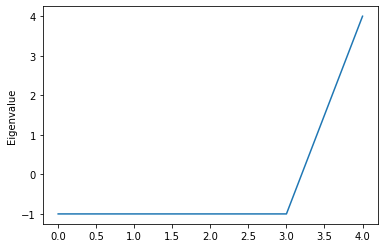

```
eigen values for K5_3_graph
[-1. -1. -1. -1. -1. -1.  2.  4.]
```

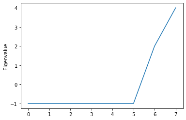

```
eigen values for K5_3e_graph
[-1.77987114 -1.         -1.         -1.         -1.         -0.33658584
  2.05492255  4.06153444]
```

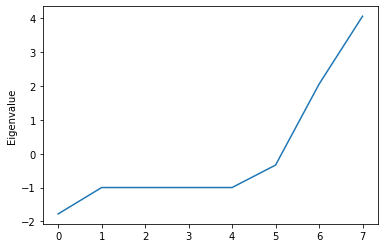

```
eigen values for bipartite B2.3 graph
[-2.44948974e+00  0.00000000e+00  0.00000000e+00  2.08925759e-16
  2.44948974e+00]
```

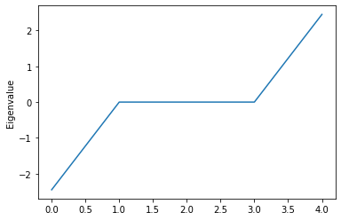

```
eigen values for 5-vertex star
[-2.  0.  0.  0.  2.]
```

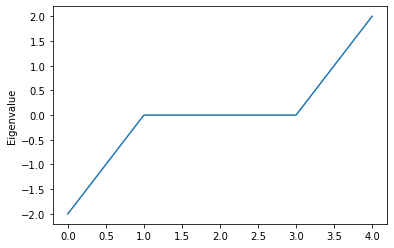

```
eigen values for path graph
[-1.73205081e+00 -1.00000000e+00 -3.29824209e-17  1.00000000e+00
  1.73205081e+00]
```

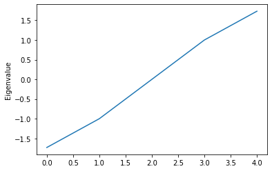

```python
def eigenvalue(graph):
  y = np.sort(np.linalg.eigvals(graph.data))
  print(y)
  plt.plot(y)
  plt.ylabel("Eigenvalue")
  plt.show()

#  Graph spectrum for K5 graph
print("eigen values for K5_graph")
eigenvalue(Graph_k5)
#  Graph spectrum for K5_3_graph
print("eigen values for K5_3_graph")
eigenvalue(Graph_K5_3)
#  Graph spectrum for K5_3e_graph
print("eigen values for K5_3e_graph")
eigenvalue(Graph_K5_3e)
#  Graph spectrum for bipartite B2.3 graph
print("eigen values for bipartite B2.3 graph")
eigenvalue(Graph_bipartite)
#  Graph spectrum for 5-vertex star
print("eigen values for 5-vertex star")
eigenvalue(Graph_star)
#  Graph spectrum for path graph
print("eigen values for path graph")
eigenvalue(Graph_path)
```

Answer the following questions:

1. What can you say about the eigenvalues of the complete graph (K5): the number of unique eigenvalues, the largest and the smallest eigenvalues, the multiplicity (how many times the same eigenvalue appears) of each eigenvalue?
2. What is the graph spectrum of the bi-partite graph, B2.3? If n1 = n and n2 = m (a general complete bi-partite graph), then what can you say about its graph spectrum? [Hint: check sqrt(n * m)] If \lambda is the eigenvalue of the bi-partite graph, will minus \lambda be also the eigenvalue?
3. What is the largest eigenvalue of the star graph S5? If S5 were generalized to an N-vertex star, what could you say about the value of its largest eigenvalue?
4. What is the largest eigenvalue of the path graph P5? As the length of the path increases, what can you say about the changes in the largest eigenvalue?
5. How does the largest eigenvalue of the path P5 (or its more generalization to an arbitrary length) compare with the largest eigenvalues of the star graph or the complete graph? If you are asked to sort the largest eigenvalue of the path, the star, and the clique) in the increasing order, what kind of relationship would you assign (E.g., \lambda{path} > or < than \lambda{star})?

**Exercise 5**: Generating the graph spectrum, or the multiset of the eigenvalues of the graph Laplacian. Write a script that calculates the eigenvalues of the graph Laplacian for each of the graphs in Exercise 1. Plot the eigenvalues in the increasing order of their values.

```
Laplacian Eigenvalues for K5_graph
[0. 5. 5. 5. 5.]
```

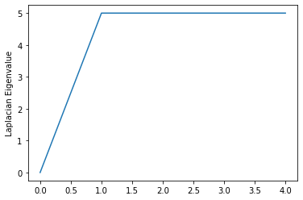

```
Laplacian Eigenvalues for K5_3_graph
[-0.  0.  3.  3.  5.  5.  5.  5.]
```

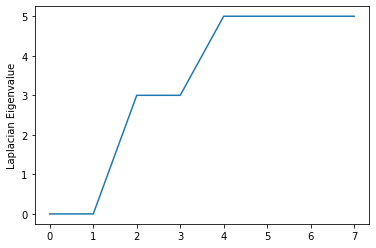

```
 Laplacian Eigenvalues for K5_3e_graph
[-0.     0.374  3.     3.485  5.     5.     5.     6.141]
```

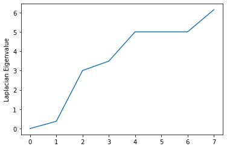

```
Laplacian Eigenvalues for bipartite B2.3 graph
[0. 2. 2. 3. 5.]
```

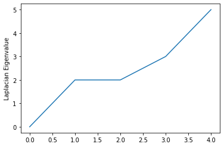

```
Laplacian Eigenvalues for 5-vertex star
[0. 1. 1. 1. 5.]
```

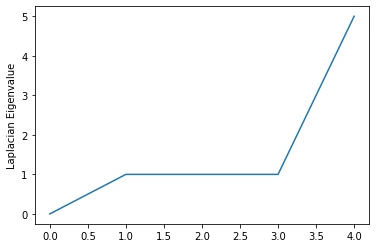

```
Laplacian Eigenvalues for path graph
[0.    0.382 1.382 2.618 3.618]
```

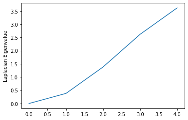

```python
def eigenvalue_lap(lap_data):
  # y = np.sort(np.linalg.eigvals(lap_data))
  y = np.around(np.sort(np.linalg.eigvals(lap_data)), decimals = 3)
  print(y)
  plt.plot(y)
  plt.ylabel("Laplacian Eigenvalue")
  plt.show()

#  Graph spectrum for laplacian K5 graph
print("Laplacian Eigenvalues for K5_graph")
eigenvalue_lap(laplacian_K5)
#  Graph spectrum for laplacian K5_3_graph
print("Laplacian Eigenvalues for K5_3_graph")
eigenvalue_lap(laplacian_K5_3)
#  Graph spectrum for laplacian K5_3e_graph
print(" Laplacian Eigenvalues for K5_3e_graph")
eigenvalue_lap(laplacian_K5_3e)
#  Graph spectrum for laplacian  bipartite B2.3 graph
print("Laplacian Eigenvalues for bipartite B2.3 graph")
eigenvalue_lap(laplacian_bipart)
#  Graph spectrum for  laplacian 5-vertex star graph
print("Laplacian Eigenvalues for 5-vertex star")
eigenvalue_lap(laplacian_star5)
#  Graph spectrum for laplacian path graph
print("Laplacian Eigenvalues for path graph")
eigenvalue_lap(laplacian_path)
```

Answer the following questions:

1. What can you say about the largest and the smallest eigenvalues?
2. What is the multiplicity (how many times the same eigenvalue appears) of the zero eigenvalue for each of the cases?
3. If K53 graph would be generalized to include c>2 components, what can you say about the multiplicity of the zero eigenvalues?
4. If graph G is connected (i.e., the number of disconnected components is one), what can you say about the multiplicity of the zero eigenvalue?
5. For the bi-partite graph, what is the value of the second smallest eigenvalue?
6. Is the vector, whose components consist of 1's only, the eigenvector of the Laplacian? If it is, then what is its corresponding eigenvalue?
7. Suppose the graph Laplacian matrix has the zero eigenvalue of multiplicity k. Can you say anything about the structure of such a graph?